# Get Dublin in-out eurostat data

Duc-Quang Nguyen

28 January 2016

#### Settings

```r
downloadData <- F
# Eurostat data tables
transfer.tb <- c('migr_dubti', 'migr_dubto', 'migr_dubri', 'migr_dubdo')

translation_chord.file <- "input/translations_DublinTransfers_chordDiagram.csv"

# Save data files
alldata.file <- "data/allData_DublinTransfer.csv"
trdata.file <- "data/data_DublinTransfer.csv"
incomingR.file <- "data/incomingR.csv"
outgoingD.file <- "data/outgoingD.csv"
```

### Get data from Eurostat

```r
if(downloadData) {
  # warning the data to download is very large over 1 Gb !

  getData <- function(dataID) {
  cat("\n", dataID)
   dat <- get_eurostat(dataID, time_format = "raw", cache = F)
   data <- cbind(label_eurostat(dat), iso2 = dat$geo)

    # transform dates efficiently!
    times <- unique(data$time)
    times <- structure(eurostat:::eurotime2date(times, last = FALSE), names = as.character(times))
    data$time <- times[match(data$time, names(times))]
    data
  }
  data.dl <- lapply(transfer.tb, getData)

  filterData <- function(df) {
    df %>% filter(leg_prov == "Total requests", duration == "Total") %>%
      select(one_of(c('partner', 'geo', 'values', 'iso2', 'time')))
  }
  data.read <- rbind(
    cbind(filterData(data.dl[[1]]), type="incoming"),
    cbind(filterData(data.dl[[2]]), type="outgoing")
  )

  write.csv(data.read, file = alldata.file, row.names = F)
  data <- data.read %>% filter(time == max(data.read$time)) %>% select(-time)
  write.csv(data, file = trdata.file, row.names = F)

  # clean up incoming requests
  incomingR <- data.dl[[3]] %>% filter( request == "Requests",
    leg_prov == "Total requests")
  write.csv(incomingR, file = incomingR.file, row.names = F)

  # clean up outgoing decisions
  outgoingD <-  data.dl[[4]] %>% filter( leg_prov == "Total requests",
    partner == "Total", request == "Requests") %>%
    select(-unit, -leg_prov, -request)
  write.csv(outgoingD, file = outgoingD.file, row.names = F)
} else {
  data <- read.csv(alldata.file, stringsAsFactors = FALSE, check.names = F)
  incomingR <- read.csv(incomingR.file, stringsAsFactors = FALSE, check.names = F)
  outgoingD <- read.csv(outgoingD.file, stringsAsFactors = FALSE, check.names = F)
}
```

#### Check the incoming and outgoing balance!

```r
  #
  data %<>% filter(time != "2008-01-01")

  data %>% filter(partner == "Total") %>% group_by(type) %>%
  dplyr::summarise(tot = sum(values, na.rm = T))
```

```
## Source: local data frame [2 x 2]
##
##       type   tot
##      (chr) (int)
## 1 incoming 60908
## 2 outgoing 84726
```

### Shape the data

```r
  data %<>% filter(partner != "Total") %>%
    group_by(partner, geo, iso2, type) %>%
    dplyr::summarise(tot = sum(values, na.rm = T)) %>% ungroup()

  data %<>% rename(iso2.from = iso2)

  data$iso2.to <- countrycode(data$partner, "country.name", "iso2c")
  stopifnot(!any(is.na(data$iso2.to)))
  dd <- data %>% select(tot, iso2.from, iso2.to, type)

  dd %>% group_by(iso2.from, type) %>% dplyr::summarise(tot = sum(tot, na.rm = T)) %>%
    group_by(type) %>% dplyr::summarise(tot = sum(tot))
```

```
## Source: local data frame [2 x 2]
##
##       type   tot
##      (chr) (int)
## 1 incoming 60908
## 2 outgoing 84726
```

```r
  dd %>% group_by(iso2.to, type) %>% dplyr::summarise(tot = sum(tot, na.rm = T)) %>%
    group_by(type) %>% dplyr::summarise(tot = sum(tot))
```

```
## Source: local data frame [2 x 2]
##
##       type   tot
##      (chr) (int)
## 1 incoming 60908
## 2 outgoing 84726
```

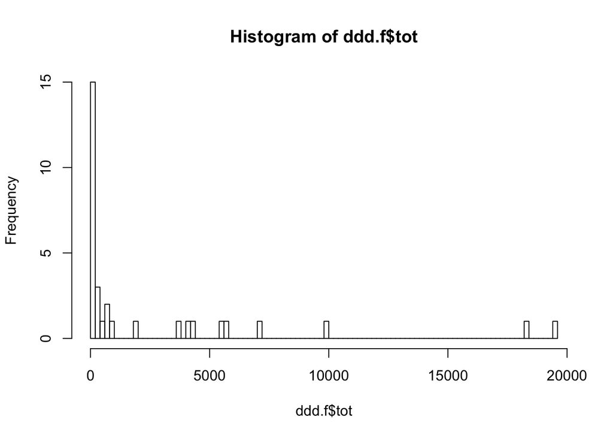

```r
  ########### TAKE ONLY OUTGOING TRANSFERS  ############
  ## find countries with unfrequent transfer (both from and towards)
  ddd <- filter(dd, type == "outgoing") %>% select(-type)
  ddd.f <- ddd %>% group_by(iso2.from) %>% dplyr::summarise(tot = sum(tot, na.rm = T)) %>% ungroup()
  ddd.t <- ddd %>% group_by(iso2.to) %>% dplyr::summarise(tot = sum(tot, na.rm = T)) %>% ungroup()

  hist(ddd.f$tot, breaks = 100)
```

```r
  quantile(ddd.f$tot, 0.5)
```

```
##   50%
## 224.5
```

```r
  threshold <- 5000
  iso2agg.f <- ddd.f[ddd.f$tot < threshold, "iso2.from"] %>% unlist(use.names = F)
  iso2agg.t <- ddd.t[ddd.t$tot < threshold, "iso2.to"] %>% unlist(use.names = F)
  iso2agg <- intersect(iso2agg.f, iso2agg.t)

  ## aggregate countries
  ddd %>% mutate(iso2.from = replace(iso2.from, iso2.from %in% iso2agg, "autres")) %>%
    mutate(iso2.to = replace(iso2.to, iso2.to %in% iso2agg, "autres")) -> ddd

  df <- ddd %>% group_by(iso2.from, iso2.to) %>% dplyr::summarise(tot = sum(tot, na.rm = T)) %>% ungroup()

  tmp <- df %>% spread(iso2.from, tot)
  ot <- tmp %>% select(-iso2.to)
  rownames(ot) <- tmp[,1] %>% unlist(use.names = F)
  ot <- as.matrix(ot)

  colnames(ot) <- ifelse(colnames(ot) == "UK", "GB", colnames(ot))
  colnames(ot) <- ifelse(colnames(ot) == "EL", "GR", colnames(ot))

  stopifnot(all(rownames(ot) %in% colnames(ot)))
  ot <- ot[,order(colnames(ot))]
  ot <- ot[order(rownames(ot)),]
  stopifnot(rownames(ot) == colnames(ot))

  colSums(ot, na.rm = T)
```

```
##     AT autres     BE     CH     DE     FR     GB     GR     IT     NO
##   7096   8623   5484  19517  18331   4093   3783   1805    127   5690
##     PL     SE
##    231   9946
```

```r
  dimnames(ot) <- list(to = rownames(ot), from = colnames(ot))
```

### Plot chord diagrams

```r
## Read translation csv
txt <- read.csv(translation_chord.file, row.names = 1, stringsAsFactors = F)

## Plot setting
groupnamePadding <- 5
margin  <- 53
groupnameFontsize <- 12
ticklabelFontsize <- 0
showTicks <- F
height <- 600

for(lang in colnames(txt)) {
#for(lang in "IT") {

  chord_outgoing.file <- paste0("chordDublin_outgoing_", lang, ".html")
  chord_incoming.file <- paste0("chordDublin_incoming_", lang, ".html")

  mat <- ot
  pays <- rownames(mat)
  pays[pays != "autres"] <- countryTranslation(pays[pays != "autres"], lang)[,2]
  if(lang == 'EN') {
    pays[pays == "United Kingdom"] <- "UK"
  }

  pays[pays == "autres"] <- txt['otherEUcountries', lang]
  dimnames(mat) <- list(to = pays, from = pays)
  tooltipGroupConnector <- " &#x25B6; "
  if(lang == 'AR') {
    tooltipGroupConnector <- " &#x25C0; "
    groupnameFontsize <- groupnameFontsize + 1
  }
  if(lang == 'JA') {
    margin <- margin + 7
  }

  # plot chord diagram
  chord.out <- chorddiag(t(mat), groupnamePadding = groupnamePadding, groupnameFontsize = groupnameFontsize, tooltipGroupConnector = tooltipGroupConnector,
    groupColors = swi_rpal, margin = margin, ticklabelFontsize = ticklabelFontsize, height = height, showTicks = showTicks)
  chord.out$sizingPolicy$browser$defaultWidth <- "100%"

  saveWidget(chord.out, file = "chordDublin_outgoing_tmp.html", selfcontained = FALSE, libdir = "js")

  swi_widget("chordDublin_outgoing_tmp.html", chord_outgoing.file,
    h2 = txt["outgoing.title", lang],
    descr =  txt["descr", lang],
    h3 = "",
    source = paste0(txt["source", lang], ": ",
      htmlLink("http://ec.europa.eu/eurostat/en/web/products-datasets/-/MIGR_DUBTO", txt["source.name", lang]),
      " | ", txt["code", lang], ": ", htmlLink("https://github.com/mattflor/chorddiag", "chorddiagR")),
      author = paste0(htmlLink("https://twitter.com/duc_qn", "Duc-Quang Nguyen"), " - swissinfo.ch"),
      footer = paste0(txt['otherEUcountries', lang], ": ", paste(countryTranslation(iso2agg, lang)[,2], collapse =", "))
  )

  # chord.inc <- chorddiag(mat, groupnamePadding = groupnamePadding, groupnameFontsize = groupnameFontsize,
  # groupColors = swi_rpal, margin = margin, ticklabelFontsize = ticklabelFontsize, height = height,  showTicks = showTicks)
  # chord.inc$sizingPolicy$browser$defaultWidth <- "100%"
  # saveWidget(chord.inc, file = "chordDublin_incoming_tmp.html", selfcontained = FALSE, libdir = "js")
  #
  # swi_widget("chordDublin_incoming_tmp.html", chord_incoming.file,
  # h2 = "Transferts entrants Dublin 2009-2014",
  # h3 = "",
  # descr = descr,
  # source = paste0("source: ", htmlLink("http://ec.europa.eu/eurostat/en/web/products-datasets/-/MIGR_DUBTO", "Eurostat"), " | code:", htmlLink("https://github.com/mattflor/chorddiag", "chorddiagR")),
  #   footer = footer
  # )

}
```

## Compute incoming transfers vs requests

> From a long-term perspective, during the five-year period from 2009 to 2013, on average some 55 000 outgoing Dublin requests were made annually. 73 % of the outgoing requests were accepted, but only some 26 %(41) of the outgoing requests resulted in the physical transfer of a person from one EU+ country to another (on average, about 14 000 persons annually)(42). The proportion of outgoing requests corresponded on average to about 15% of the number of registered asylum applicants. The proportion of physical Dublin transfers to the number of applicants for international protection in the EU+(43) was about 4 %(44)

```r
  data <- read.csv(alldata.file, stringsAsFactors = FALSE, check.names = F)
  data %<>% filter(time != "2008-01-01")
  incomingT <- data %>% filter(type == "outgoing", partner != "Total") %>% group_by(partner) %>%
    dplyr::summarise(total = sum(values, na.rm = T)) %>% ungroup()

  outD <- outgoingD %>% filter(time != "2008-01-01", time != "2014-01-01", partner == "Total") %>%
    select(-partner)
  outD %>% spread(decision, values) %>% group_by(geo, iso2) -> outD

  outD <- left_join(
    outD %>% dplyr::summarise(`Requests accepted` = sum(`Requests accepted`, na.rm = T)) %>% ungroup(),
    outD %>% dplyr::summarise(Total = sum(Total, na.rm = T)) %>% ungroup()
  )
  outD$percAcc <- outD$`Requests accepted` / outD$`Total`
  sum(outD$`Requests accepted`) / sum(outD$Total)
```

```
## [1] 0.7919172
```

```r
  # incomingT <- data %>% filter(type == "incoming", partner == "Total") %>% group_by(geo, iso2) %>%
  #   dplyr::summarise(total = sum(values, na.rm = T)) %>% ungroup()

  incomingR  %<>% filter(time != "2008-01-01")
  incoming <- incomingR %>%
    group_by(iso2, geo) %>% dplyr::summarise(incomingR = sum(values, na.rm = T)) %>% ungroup()

  # Compute some statistcs
  yearlyIncomingR <- as.data.frame(incomingR %>% filter(partner == "Total") %>% group_by(time) %>% dplyr::summarise(yearlyR = sum(values, na.rm = T)) %>% ungroup())
  mean(yearlyIncomingR$yearlyR)
```

```
## [1] 50062.67
```

```r
  yearlyIncomingT <- data %>% filter(type == "outgoing", partner != "Total") %>% group_by(time) %>%
    dplyr::summarise(yearlyT = sum(values, na.rm = T)) %>% ungroup()
  mean(yearlyIncomingT$yearlyT)
```

```
## [1] 14121
```

```r
  incoming <- incoming %>% left_join(rename(incomingT, geo = partner))
```

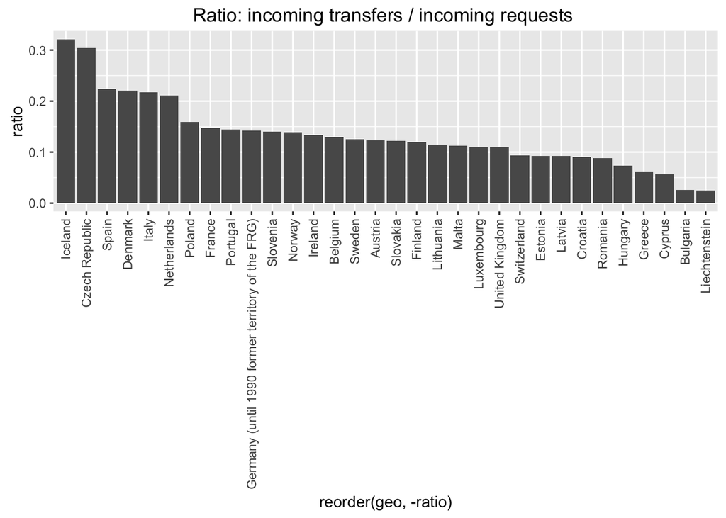

```r
  incoming$ratio <- incoming$total / incoming$incomingR

  library(ggplot2)
  ggplot(data = incoming, aes(x=reorder(geo,-ratio), y = ratio)) + geom_bar(stat = "identity") +
    theme(axis.text.x=element_text(angle=90,hjust=1,vjust=0.5)) +
    ggtitle("Ratio: incoming transfers / incoming requests ")
```

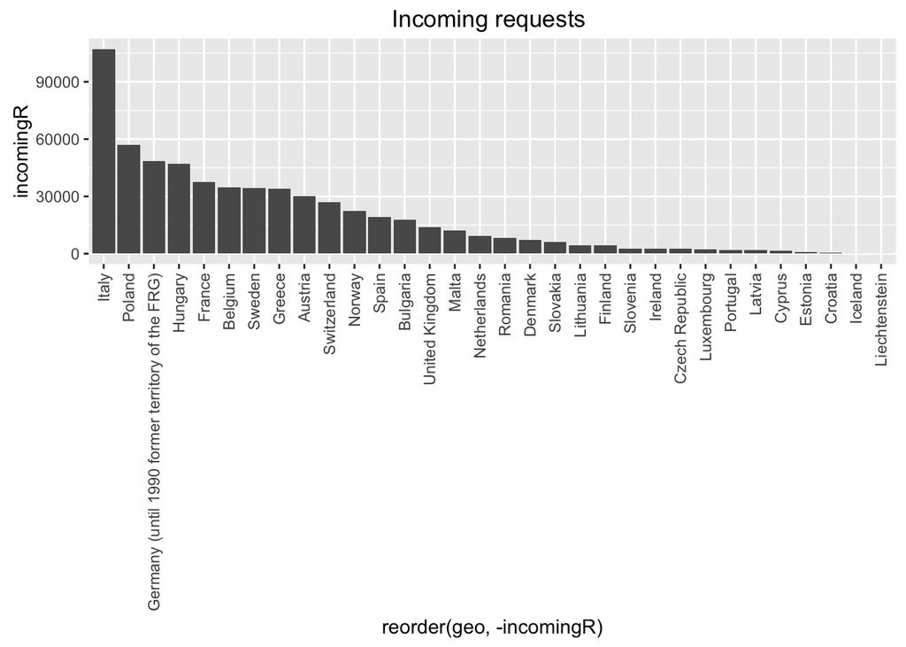

```r
  ggplot(data = incoming, aes(x=reorder(geo,-incomingR), y = incomingR)) + geom_bar(stat = "identity") +
    theme(axis.text.x=element_text(angle=90,hjust=1,vjust=0.5)) +
    ggtitle("Incoming requests ")
```

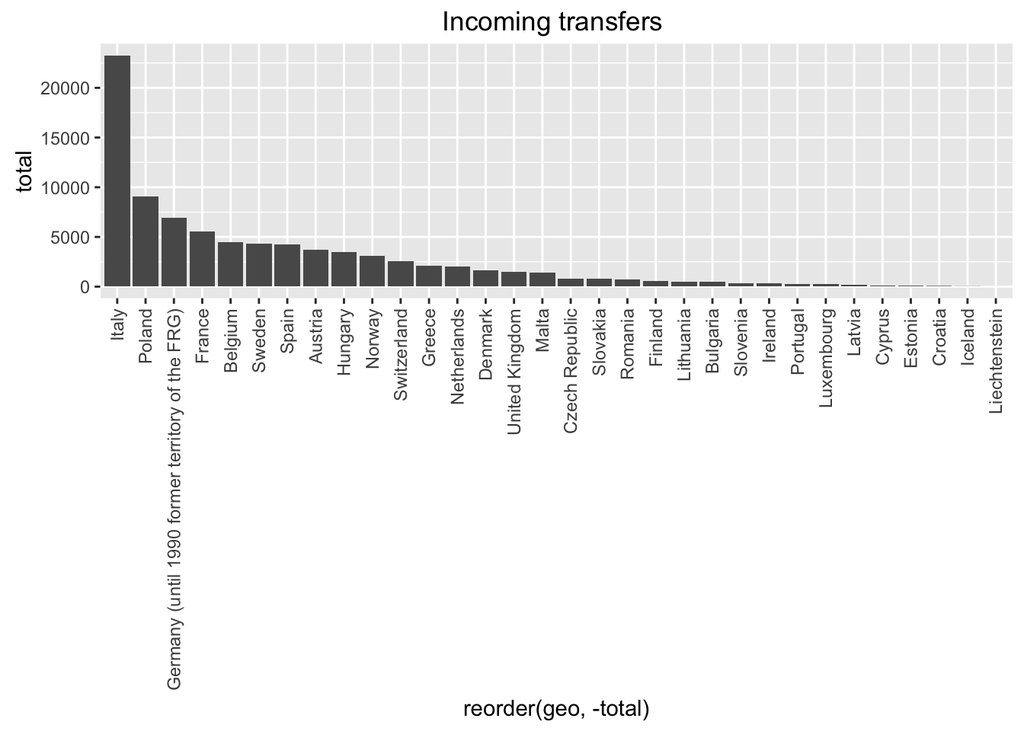

```r
  ggplot(data = incoming, aes(x=reorder(geo,-total), y = total)) + geom_bar(stat = "identity") +
    theme(axis.text.x=element_text(angle=90,hjust=1,vjust=0.5)) +
        ggtitle("Incoming transfers ")
```

```r
  # export data for datawrapper
  write.csv(incoming %>% filter(!iso2 %in% c("LI", "IS")) %>% select(-iso2), file = "output/incomingRequestTransfer_all.csv", row.names = F)
```

### Between 2009-2014, on average

- 50063 outgoing Dublin requests were made annually
- 79 % of outgoing requests were accepted between 2009-2013 (2014 data not complete!)
- only 28 % outgoing requests resulted in the physical transfer of a person from one EU+ country to another (on average 14121 persons annually)
- The proportion of outgoing requests corresponds to 12 % of the number of registered asylum applicants in EU+ countries